# Padma River Course using Landsat

Saad Tarik

4/21/2019

In 2013, I finished a class project where I used decision tree classification to identify the changes in river course of the [Padma River](https://en.wikipedia.org/wiki/Padma_River) in Bangladesh. Later, NASA published a story titled [World of Change: Padma River](https://earthobservatory.nasa.gov/world-of-change/PadmaRiver) visualizing changes from 1988 to 2018. Here, I am reproducing the class project using R from 1989 to 2019 using Random Forest.

## Load Raw Files

```r
library(raster)
```

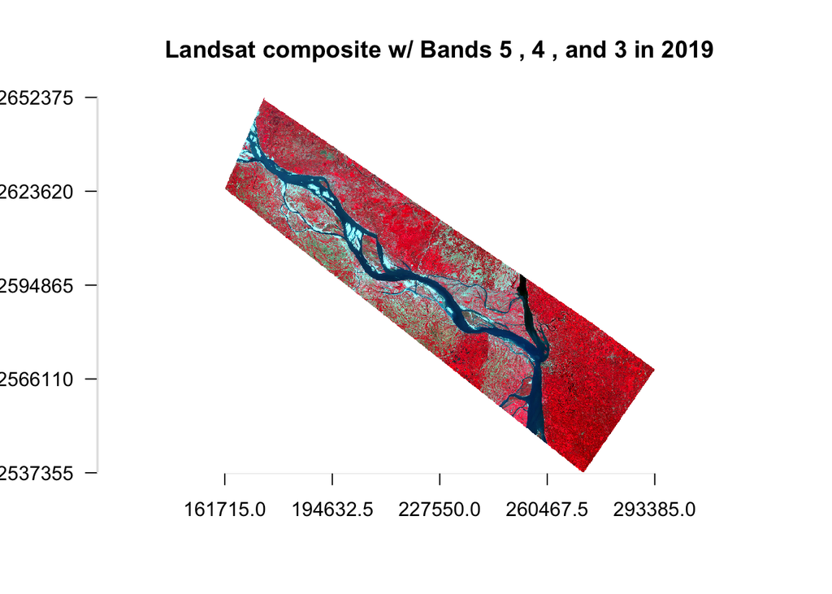

```r
aoi <- shapefile("Raw_Data/Clipped_River.shp") # Area of Interest
aoi <- spTransform(aoi, "+proj=utm +zone=46 +datum=WGS84 +units=m +no_defs +ellps=WGS84 +towgs84=0,0,0 ") # Transform to Landsat projection
all_1989 <- list.files(path = "Raw_Data", pattern = glob2rx("*1989*band*.tif$"), full.names = TRUE)
all_2019 <- list.files(path = "Raw_Data", pattern = glob2rx("*2019*band*.tif$"), full.names = TRUE)

# 1989
all_1989_st <- stack(all_1989)
all_1989_st_names <- rep(NA, nlayers(all_1989_st))
for (i in 1:nlayers(all_1989_st)) {
  all_1989_st_names[i] <- paste0("B", i)
}
names(all_1989_st) <- all_1989_st_names
all_1989_st <- mask(all_1989_st, aoi)
all_1989_st_crop <- crop(all_1989_st, aoi)

# 2019
all_2019_st <- stack(all_2019)
all_2019_st_names <- rep(NA, nlayers(all_2019_st))
for (i in 1:nlayers(all_2019_st)) {
  all_2019_st_names[i] <- paste0("B", i)
}
names(all_2019_st) <- all_2019_st_names
all_2019_st <- mask(all_2019_st, aoi)
all_2019_st_crop <- crop(all_2019_st, aoi)
R <- 5
G <- 4
B <- 3
plotRGB(all_2019_st_crop, r = R, g = G, b = B, stretch = "lin", axes = TRUE,
        main = paste("Landsat composite w/ Bands", R,",", G,", and", B, "in 2019"))
box(col = "white")
```

## Train Data

I created training polygons for both 1989 and 2019 images. The training polygons have to two classes: River and No River.

```r
## Load Training set
training_1989 <- shapefile("Raw_Data/Train_1989.shp")
ex_train_1989 <- extract(all_1989_st_crop, training_1989, df = TRUE)

training_2019 <- shapefile("Raw_Data/Train_2019.shp")
ex_train_2019 <- extract(all_2019_st_crop, training_2019, df = TRUE)
```

The next step is to rasterize the polygon objects. It creates a raster with the values from the training polygons. Then the Landsat image bands are masked and combined with the newly-created raster containing the classes from the previous step.

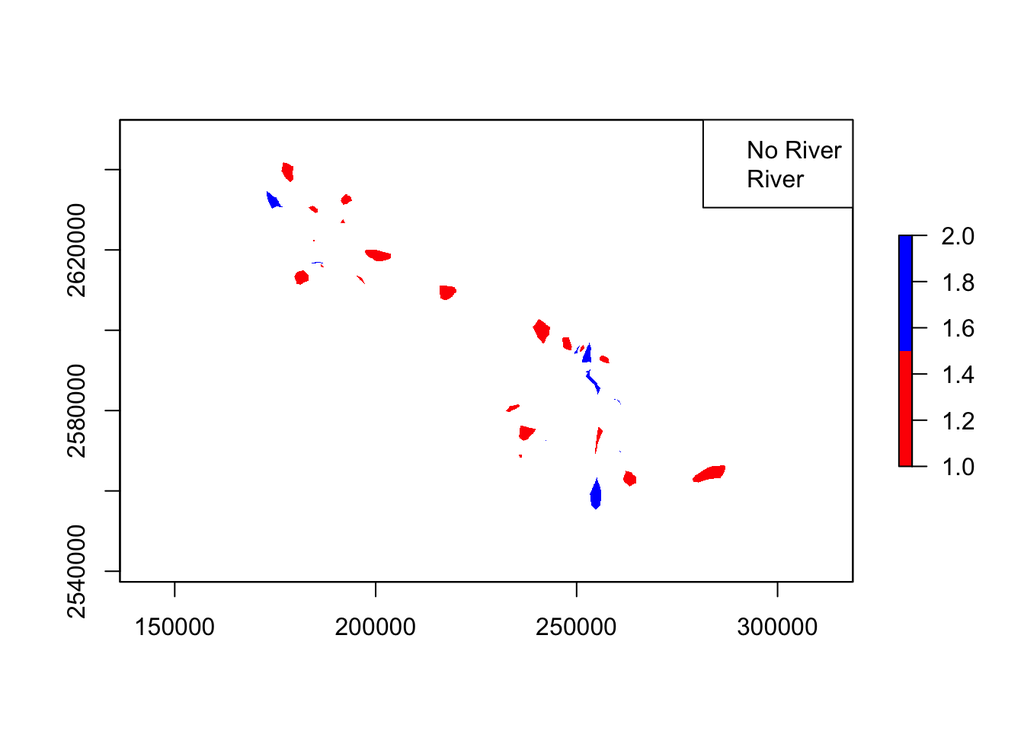

```r
# 1989
classes_1989 <- rasterize(training_1989, all_1989_st_crop, field = "Class_ID")
names(classes_1989) <- "Classes"
plot(classes_1989, col = c("red", "blue"))
legend("topright", legend = c("No River", "River"))
```

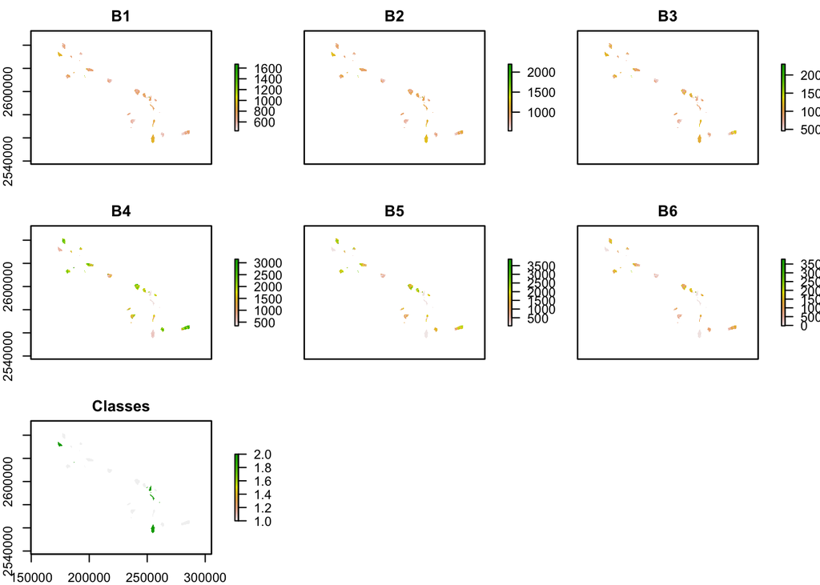

```r
mask_train_1989 <- mask(all_1989_st_crop, classes_1989)
# Combine the classes raster with the masked raster
mask_train_1989_class <- addLayer(mask_train_1989, classes_1989)
plot(mask_train_1989_class)
```

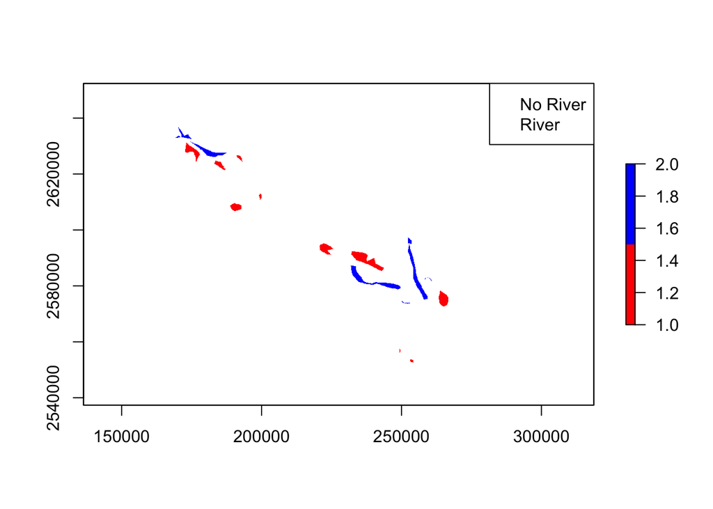

```r
# 2019
classes_2019 <- rasterize(training_2019, all_2019_st_crop, field = "Class_ID")
names(classes_2019) <- "Classes"
plot(classes_2019, col = c("red", "blue"))
legend("topright", legend = c("No River", "River"))
```

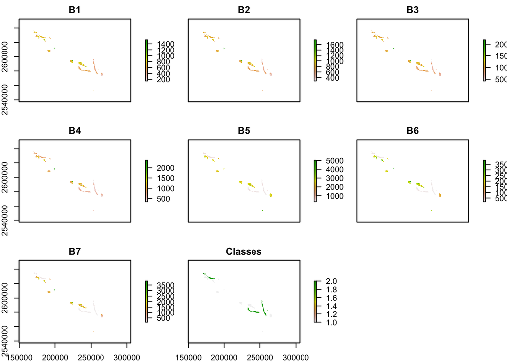

```r
mask_train_2019 <- mask(all_2019_st_crop, classes_2019)
# Combine the classes raster with the masked raster
mask_train_2019_class <- addLayer(mask_train_2019, classes_2019)
plot(mask_train_2019_class)
```

Then a `data.frame` object is created which will be used as an input in the `randomForest` function. This object includes the training data.

```r
# 1989
mask_train_1989_values <- getValues(mask_train_1989_class) # Get the values
mask_train_1989_values <- na.omit(mask_train_1989_values) # Remove NAs
df.mask_train_1989_values <- data.frame(mask_train_1989_values) # Convert to data frame
df.mask_train_1989_values$Classes <- as.factor(df.mask_train_1989_values$Classes) # Convert classes to factor type

# 2019
mask_train_2019_values <- getValues(mask_train_2019_class) # Get the values
mask_train_2019_values <- na.omit(mask_train_2019_values) # Remove NAs
df.mask_train_2019_values <- data.frame(mask_train_2019_values) # Convert to data frame
df.mask_train_2019_values$Classes <- as.factor(df.mask_train_2019_values$Classes) # Convert classes to factor type
```

## Running Random Forest

Now we have all the necessary inputs for the `randomForest` function. This function belongs to the package `randomForest`. It produces a model object as an output which can be used for the prediction in the next step.

```r
library(randomForest)
model_rf_1989 <- randomForest(x = df.mask_train_1989_values[, c(1:6)],
                              y =df.mask_train_1989_values$Classes,
                              importance = TRUE)

colnames(model_rf_1989$confusion) <- c("No River", "River", "Class Error")
rownames(model_rf_1989$confusion) <- c("No River", "River")
model_rf_1989
```

```
##
## Call:
##  randomForest(x = df.mask_train_1989_values[, c(1:6)], y = df.mask_train_1989_values$Classes,      importance = TRUE)
##                Type of random forest: classification
##                      Number of trees: 500
## No. of variables tried at each split: 2
##
##         OOB estimate of  error rate: 0.03%
## Confusion matrix:
##          No River River  Class Error
## No River   139223    14 0.0001005480
## River          39 40932 0.0009518928
```

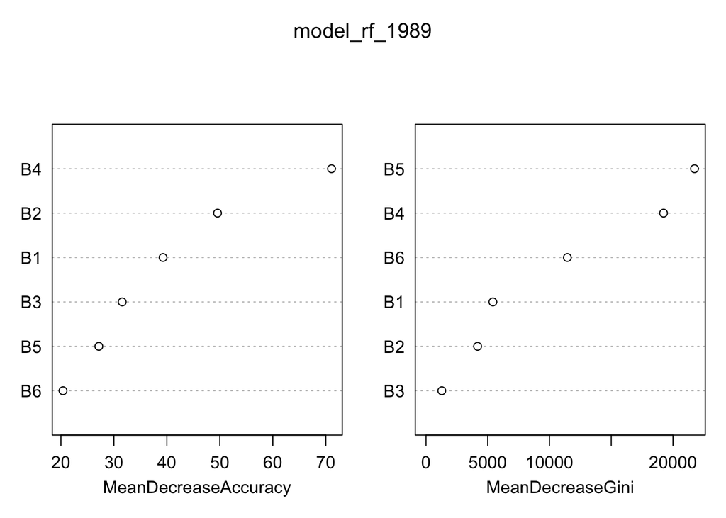

```r
varImpPlot(model_rf_1989)
```

```r
model_rf_2019 <- randomForest(x = df.mask_train_2019_values[, c(1:7)],
                              y =df.mask_train_2019_values$Classes,
                              importance = TRUE)

colnames(model_rf_2019$confusion) <- c("No River", "River", "Class Error")
rownames(model_rf_2019$confusion) <- c("No River", "River")
model_rf_2019
```

```
##
## Call:
##  randomForest(x = df.mask_train_2019_values[, c(1:7)], y = df.mask_train_2019_values$Classes,      importance = TRUE)
##                Type of random forest: classification
##                      Number of trees: 500
## No. of variables tried at each split: 2
##
##         OOB estimate of  error rate: 0.02%
## Confusion matrix:
##          No River River  Class Error
## No River    91134    15 0.0001645657
## River          25 79963 0.0003125469
```

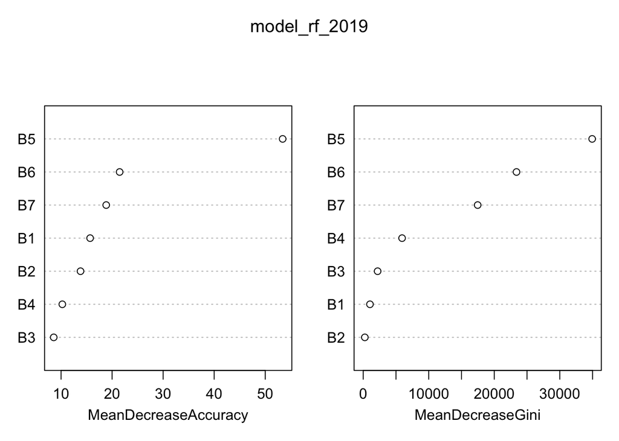

```r
varImpPlot(model_rf_2019)
```

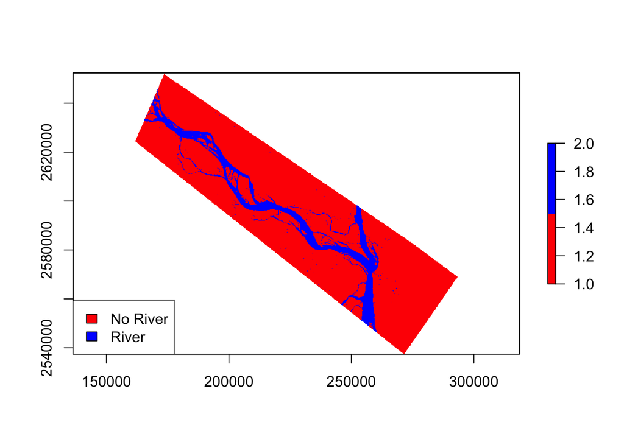

```r
# Prediction
predict_rf_1989 <- predict(all_1989_st_crop, model = model_rf_1989, na.rm = TRUE)
predict_rf_2019 <- predict(all_2019_st_crop, model = model_rf_2019, na.rm = TRUE)

# Visualilze
plot(predict_rf_2019, col = c("red", "blue"))
legend("bottomleft", legend = c("No River", "River"), fill = c("red", "blue"), bg = "white")
```

To visualize the final result of the changes in river course from 1989 to 2019, we need to set the ‘No River’ class as `NA`. Then the river classes from 1989 and 2019 are plotted on top of the other. For this purpose, the `quickPlot` package is used.

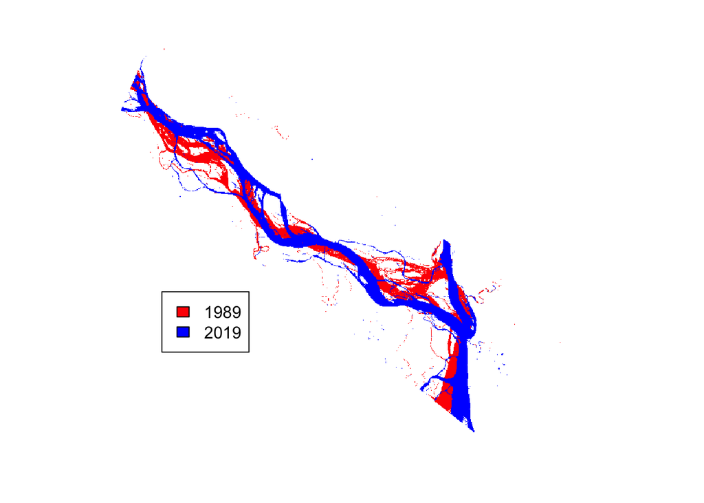

```r
# Set No River as NA export as polygon
predict_rf_1989[predict_rf_1989 == 1] <- NA
predict_rf_2019[predict_rf_2019 == 1] <- NA

# Combined Plot
library(quickPlot)
clearPlot()
Plot(predict_rf_1989, col = "red", legend = FALSE, new = TRUE, title = "")
Plot(predict_rf_2019, col = "blue", legend = FALSE, addTo = "predict_rf_1989", title = FALSE)
legend("bottomleft", legend = c("1989", "2019"), fill = c("red", "blue"), bg = "white")
```